# temp-159975159235080725

- Libraries
- Data Loading
- Exploratory Data Analysis
  - Labels
    - Data Provider Distribution
    - ISUP Grade
    - Groupby ["data_provider", "isup"]
  - Images
    - Biopsy Images
    - Masks
    - Preview Both Image and Mask
    - Image Resolution Scatterplot and Distplot
- Suspicious Images
  - Images with No Masks
  - Mislabelled Images
  - Masks with Background Only
  - `isup_grade > 0` but No Cancerous Labelled
- Conclusion of EDA & Labelled Data Cleansing

# Libraries

Below are the libraries used for EDA

```python
# for data processing
import pandas as pd
import numpy as np
import random

# os
import os
from glob import glob

# image related
import openslide
import skimage.io
import cv2
import PIL
from IPython.display import Image, display

# visualization
import matplotlib
import matplotlib.pyplot as plt
import plotly.graph_objs as go
import seaborn as sns

plt.style.use('seaborn-pastel')

# loading bar
from tqdm.notebook import tqdm

# multiprocessing
from joblib import Parallel, delayed
```

# Data Loading

Bear in mind that the data is hosted on the Kaggle cloud. Hence, paths are relative to the Kaggle cloud. Backup data will be placed on Google Cloud.

```python
# base path
PATH = '../input/prostate-cancer-grade-assessment'

# images and masks folders
img_dir = f'{PATH}/train_images'
mask_dir = f'{PATH}/train_label_masks'

# labels of training data and test data
label_df = pd.read_csv(f'{PATH}/train.csv').set_index('image_id')
#test = pd.read_csv(f'{PATH}/test.csv')
#submission = pd.read_csv(f'{PATH}/sample_submission.csv')
```

# Helper Functions

This section is for helper functions used throughout the EDA.

# Exploratory Data Analysis (EDA)

This notebook focuses on EDA of the labels and the image datasets

## Labels

```python
label_df.head()
```

| image_id | data_provider | isup_grade | gleason_score |
| --- | --- | --- | --- |
| 0005f7aaab2800f6170c399693a96917 | karolinska | 0 | 0+0 |
| 000920ad0b612851f8e01bcc880d9b3d | karolinska | 0 | 0+0 |
| 0018ae58b01bdadc8e347995b69f99aa | radboud | 4 | 4+4 |
| 001c62abd11fa4b57bf7a6c603a11bb9 | karolinska | 4 | 4+4 |
| 001d865e65ef5d2579c190a0e0350d8f | karolinska | 0 | 0+0 |

```python
label_df.info()
```

```
<class 'pandas.core.frame.DataFrame'>
Index: 10616 entries, 0005f7aaab2800f6170c399693a96917 to ffe9bcababc858e04840669e788065a1
Data columns (total 3 columns):
 #   Column         Non-Null Count  Dtype
---  ------         --------------  -----
 0   data_provider  10616 non-null  object
 1   isup_grade     10616 non-null  int64
 2   gleason_score  10616 non-null  object
dtypes: int64(1), object(2)
memory usage: 331.8+ KB
```

### Data Provider Distribution

```python
label_df['data_provider'].value_counts()
```

```
karolinska    5456
radboud       5160
Name: data_provider, dtype: int64
```

```python
data_prov_pct = label_df['data_provider'].value_counts() / label_df.shape[0] ; data_prov_pct
```

```
karolinska    0.513941
radboud       0.486059
Name: data_provider, dtype: float64
```

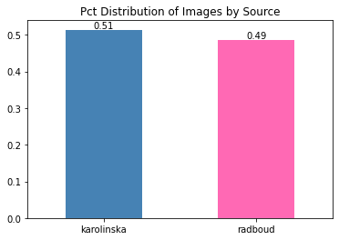

```python
ax = data_prov_pct.plot(kind='bar', color=['steelblue', 'hotpink'], rot=0, figsize=(6, 4), title='Pct Distribution of Images by Source')
for p in ax.patches:
    ax.annotate("%.2f" % p.get_height(), (p.get_x() + p.get_width() / 2., p.get_height()),
                ha='center', va='center', xytext=(0, 5), textcoords='offset points')
```

### ISUP Grade

```python
label_df['isup_grade'].value_counts()
```

```
0    2892
1    2666
2    1343
4    1249
3    1242
5    1224
Name: isup_grade, dtype: int64
```

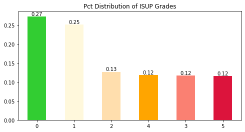

```python
isup_pct = label_df['isup_grade'].value_counts() / label_df.shape[0]
ax = isup_pct.plot(kind='bar', color=['limegreen','cornsilk','navajowhite', 'orange', 'salmon','crimson'], rot=0, figsize=(8, 4), title='Pct Distribution of ISUP Grades')
for p in ax.patches:
    ax.annotate("%.2f" % p.get_height(), (p.get_x() + p.get_width() / 2., p.get_height()),
                ha='center', va='center', xytext=(0, 5), textcoords='offset points')
```

- ISUP grades 2 to 5 seeems evenly distributed and grades 0 and 1 seems to have samples. Normal to have more non cancerous labels in dataset. Suitable to do stratified sampling and cross validation.
- In short, dataset is not balanced for Grades 0 and 1

### Groupby ["data_provider", "isup"]

```python
label_df.groupby(['data_provider', 'isup_grade']).size()
```

```
data_provider  isup_grade
karolinska     0             1925
               1             1814
               2              668
               3              317
               4              481
               5              251
radboud        0              967
               1              852
               2              675
               3              925
               4              768
               5              973
dtype: int64
```

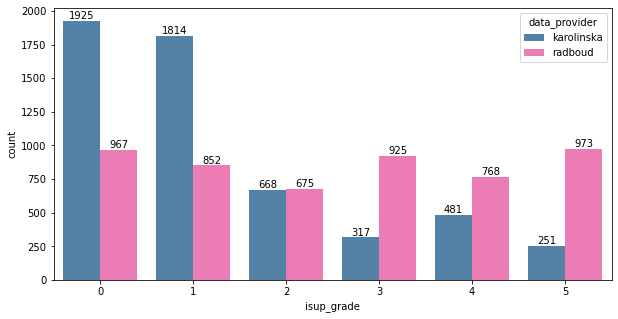

```python
plt.figure(figsize=(10, 5))
ax = sns.countplot(x="isup_grade", hue="data_provider", data=label_df, palette=['steelblue', 'hotpink'])
for p in ax.patches:
    ax.annotate("%.0f" % (p.get_height()), (p.get_x() + p.get_width() / 2., p.get_height()),
                ha='center', va='center', xytext=(0, 5), textcoords='offset points')
```

```python
label_df.groupby(['data_provider', 'isup_grade']).size() / label_df.shape[0]*100
```

```
data_provider  isup_grade
karolinska     0             18.133007
               1             17.087415
               2              6.292389
               3              2.986059
               4              4.530897
               5              2.364356
radboud        0              9.108892
               1              8.025622
               2              6.358327
               3              8.713263
               4              7.234363
               5              9.165411
dtype: float64
```

- Karolinka has most of its labels coming from ISUP grades 0 and 1. Be aware when stratify sampling them.
- Radbound on the other hand seems to have closed to even distribution between the ISUP grades.

## Images

### Biopsy Images

```python
images_list = glob(img_dir + '/*.tiff')
sample_image = openslide.OpenSlide(images_list[np.random.choice(len(images_list))])
```

```python
# image properties
sample_image.properties
```

```
<_PropertyMap {'openslide.level-count': '3', 'openslide.level[0].downsample': '1', 'openslide.level[0].height': '28416', 'openslide.level[0].tile-height': '512', 'openslide.level[0].tile-width': '512', 'openslide.level[0].width': '14080', 'openslide.level[1].downsample': '4', 'openslide.level[1].hei…
```

- `'openslide.level-count': '3'` means there are 3 levels of resolution in the image.
- For image viewing, use the lowest resolution, `openslide.level[2]`
- Lowest resolution has dimensions `'openslide.level[2].width':` and `'openslide.level[2].height'`

```python
sample_image.level_dimensions
```

```
((14080, 28416), (3520, 7104), (880, 1776))
```

```python
img = sample_image.read_region(location=(0,0), level=2,size=sample_image.level_dimensions[-1])
print(img.size)
```

```
(880, 1776)
```

```python
def preview_random_img(resolution_lim=None):
    """
    Preview of lowest resolution of random biopsy image
    """
    random_image = images_list[np.random.choice(len(images_list))]
    sample_image = openslide.OpenSlide(random_image)
    img_res = sample_image.level_dimensions[-1]
    img_name = random_image.split('/')[-1].split('.')[0]

    data_provider = label_df.loc[img_name]['data_provider']
    isup = label_df.loc[img_name]['isup_grade']

    if resolution_lim:
        img = sample_image.get_thumbnail(resolution_lim)
    else:
        img = sample_image.read_region(location=(0,0), level=2,size=img_res)
    print(f"Image name: {img_name}")
    print(f"ISUP Grade: {isup}")
    print(f"Data Provider: {data_provider}")
    print(f"Resolution of image: {img_res}")
    return img
```

```
Image name: 2f3e4e71d38f7f20aad08dd262b9ca63
ISUP Grade: 0
Data Provider: karolinska
Resolution of image: (1536, 1920)
```

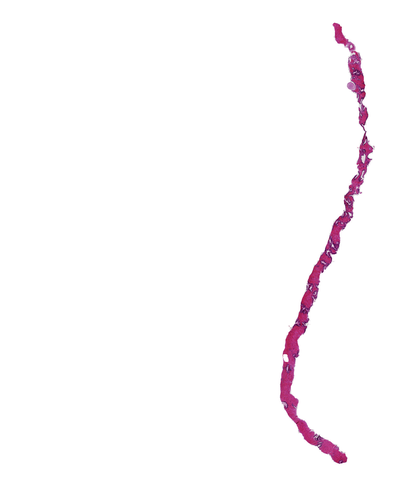

```python
preview_random_img(resolution_lim=(400, 600))
```

### Masks

- Masks labels are stored in the Red channel of RGB. Hence, need to extract the matrix in the R channel
- Map raw label values to RGB values

> **Radboud**: Prostate glands are individually labelled. Valid values are:
> - 0: background (non tissue) or unknown
> - 1: stroma (connective tissue, non-epithelium tissue)
> - 2: healthy (benign) epithelium
> - 3: cancerous epithelium (Gleason 3)
> - 4: cancerous epithelium (Gleason 4)
> - 5: cancerous epithelium (Gleason 5)

> **Karolinska**: Regions are labelled. Valid values are:
> - [0]: background (non tissue) or unknown
> - [1]: benign tissue (stroma and epithelium combined)
> - [2]: cancerous tissue (stroma and epithelium combined)

```python
masks_list = glob(mask_dir + '/*.tiff')
sample_mask = openslide.OpenSlide(masks_list[np.random.choice(len(masks_list))])
```

```python
sample_mask.properties
```

```
<_PropertyMap {'openslide.level-count': '3', 'openslide.level[0].downsample': '1', 'openslide.level[0].height': '6912', 'openslide.level[0].tile-height': '512', 'openslide.level[0].tile-width': '512', 'openslide.level[0].width': '8960', 'openslide.level[1].downsample': '4', 'openslide.level[1].heigh…
```

```python
def preview_random_mask(resolution_lim=None):

    masks_list = glob(mask_dir + '/*.tiff')
    random_mask = masks_list[np.random.choice(len(masks_list))]
    sample_mask = openslide.OpenSlide(random_mask)

    mask_name = random_mask.split('/')[-1].split('_')[0]
    data_provider = label_df.loc[mask_name]['data_provider']
    isup = label_df.loc[mask_name]['isup_grade']

    mask_res = sample_mask.level_dimensions[-1]
    mask = sample_mask.read_region((0,0), level=2, size=mask_res)

    # extract the Red channel
    mask = mask.split()[0]

    # 256 * 3 = 768
    preview_palette = np.zeros(shape=768, dtype=int)

    if data_provider == 'radboud':
        # Mapping: {0: background, 1: stroma, 2: benign epithelium, 3: Gleason 3, 4: Gleason 4, 5: Gleason 5}
        # 0,0,0 -> black
        # 127,127,127 -> grey
        # 0,255,0 -> green
        # 255,255,178 -> yellow
        # 255,127,0 -> orange
        # 255,0,0 -> red

        preview_palette[0:18] = (np.array([  0,   0,   0, 127, 127, 127,   0, 255,   0, 255, 255, 178, 255,
       127,   0, 255,   0,   0]))
    elif data_provider == 'karolinska':
        # Mapping: {0: background, 1: benign, 2: cancer}
        # 0,0,0 -> black
        # 127,127,127 -> grey
        # 255,0,0 -> red
        preview_palette[0:9] = (np.array([  0,   0,   0, 127, 127, 127, 255,   0,   0]))

    mask.putpalette(data=preview_palette.tolist())
    mask = mask.convert(mode='RGB')

    if resolution_lim:
        mask.thumbnail(size=resolution_lim, resample=0)

    print(f"Mask name: {random_mask.split('/')[-1]}")
    print(f"ISUP Grade: {isup}")
    print(f"Data Provider: {data_provider}")
    print(f"Original resolution of Mask: {mask_res}")

    return display(mask)
```

```
Mask name: b4f14cae24e001bad06e5a7e42f1002b_mask.tiff
ISUP Grade: 4
Data Provider: radboud
Original resolution of Mask: (336, 1296)
```

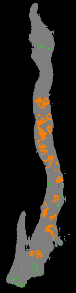

```python
preview_random_mask(resolution_lim=(400, 600))
```

### Preview Both Image and Mask

```python
def preview_img_mask(resolution_lim=None, image=None):

    """
    Preview of lowest resolution of random biopsy image and its corresponding mask
    """
    if image == None:
        random_image = images_list[np.random.choice(len(images_list))]
    else:
        random_image = img_dir + '/' + image + '.tiff'

    sample_image = openslide.OpenSlide(random_image)
    img_res = sample_image.level_dimensions[-1]
    img_name = random_image.split('/')[-1].split('.')[0]

    data_provider = label_df.loc[img_name]['data_provider']
    isup = label_df.loc[img_name]['isup_grade']

    if resolution_lim:
        img = sample_image.get_thumbnail(resolution_lim)
    else:
        img = sample_image.read_region(location=(0,0), level=2,size=img_res)

    #masks_list = glob(mask_dir + '/*.tiff')
    #random_mask = masks_list[np.random.choice(len(masks_list))]
    random_mask = mask_dir + '/' + img_name + '_mask.tiff'
    try:
        sample_mask = openslide.OpenSlide(random_mask)
    except Exception as e:
        print("Mask not found !")
        print(e)

    mask_name = random_mask.split('/')[-1].split('_')[0]
    data_provider = label_df.loc[mask_name]['data_provider']
    isup = label_df.loc[mask_name]['isup_grade']

    mask_res = sample_mask.level_dimensions[-1]
    mask = sample_mask.read_region((0,0), level=2, size=mask_res)

    # extract the Red channel
    mask = mask.split()[0]

    # 256 * 3 = 768
    preview_palette = np.zeros(shape=768, dtype=int)

    if data_provider == 'radboud':
        # Mapping: {0: background, 1: stroma, 2: benign epithelium, 3: Gleason 3, 4: Gleason 4, 5: Gleason 5}
        # 0,0,0 -> black
        # 127,127,127 -> grey
        # 0,255,0 -> green
        # 255,255,178 -> yellow
        # 255,127,0 -> orange
        # 255,0,0 -> red

        preview_palette[0:18] = (np.array([  0,   0,   0, 127, 127, 127,   0, 255,   0, 255, 255, 178, 255,
       127,   0, 255,   0,   0]))
    elif data_provider == 'karolinska':
        # Mapping: {0: background, 1: benign, 2: cancer}
        # 0,0,0 -> black
        # 127,127,127 -> grey
        # 255,0,0 -> red
        preview_palette[0:9] = (np.array([  0,   0,   0, 127, 127, 127, 255,   0,   0]))

    mask.putpalette(data=preview_palette.tolist())
    mask = mask.convert(mode='RGB')

    if resolution_lim:
        mask.thumbnail(size=resolution_lim, resample=0)

    print(f"Image name: {img_name}")
    print(f"ISUP Grade: {isup}")
    print(f"Data Provider: {data_provider}")
    print(f"Original Resolution of Image: {img_res}")
    print(f"Original resolution of Mask: {mask_res}")

    display(img)
    display(mask)
```

```
Image name: 79212be3df3e81973f9e0365920f2282
ISUP Grade: 1
Data Provider: karolinska
Original Resolution of Image: (1792, 1856)
Original resolution of Mask: (1792, 1856)
```

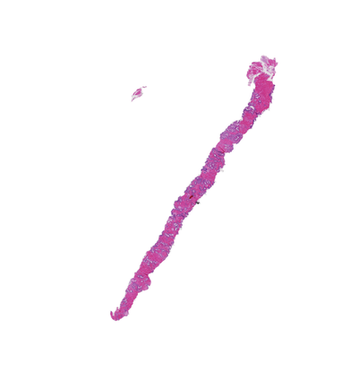

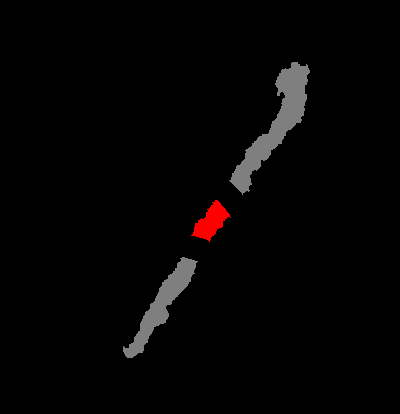

```python
preview_img_mask((400, 600))
```

### Image Resolution Scatterplot and Distplot

- Assuming we will be using highest resolution for training `level = 0`, analysis below is for `level = 0`
- Due to large amount of images, multiprocessing from `joblib` library will be used

```python
# extract height & width of each image
def extract_resolutions(img):
    sample_image = openslide.OpenSlide(img_dir + '/' + img + '.tiff')
    img_res = sample_image.level_dimensions[0]

    data_provider = label_df.loc[img]['data_provider']

    return (img, ) + (data_provider,) + img_res
```

```python
label_images = label_df.index.tolist()
list_res = Parallel(n_jobs=32)(delayed(extract_resolutions)(image) for image in tqdm(label_images))
```

```python
res_df = pd.DataFrame(list_res, columns=['image', 'data_provider', 'width', 'height'])
```

```python
res_df.head()
```

|  | image | data_provider | width | height |
| --- | --- | --- | --- | --- |
| 0 | 0005f7aaab2800f6170c399693a96917 | karolinska | 27648 | 29440 |
| 1 | 000920ad0b612851f8e01bcc880d9b3d | karolinska | 15360 | 13312 |
| 2 | 0018ae58b01bdadc8e347995b69f99aa | radboud | 5888 | 25344 |
| 3 | 001c62abd11fa4b57bf7a6c603a11bb9 | karolinska | 23904 | 28664 |
| 4 | 001d865e65ef5d2579c190a0e0350d8f | karolinska | 28672 | 34560 |

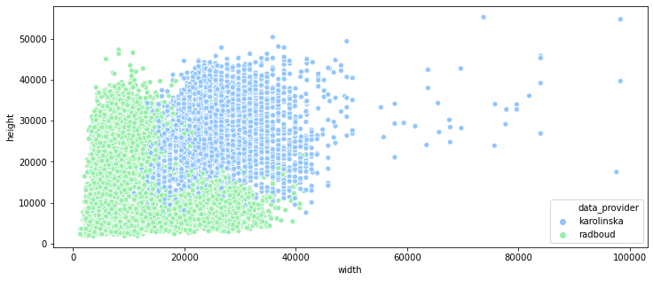

```python
plt.figure(figsize=(12, 5))
sns.scatterplot(data=res_df[['data_provider', 'width', 'height']], x="width", y="height", hue="data_provider")
```

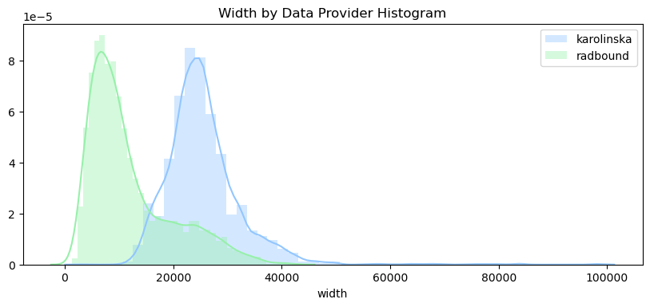

```python
plt.subplots(figsize=(10,4), dpi=100)
sns.distplot( res_df.loc[res_df.data_provider=='karolinska', "width"] ,label="karolinska")
sns.distplot( res_df.loc[res_df.data_provider=='radboud', "width"] , label="radbound")

plt.title('Width by Data Provider Histogram')
plt.legend();
```

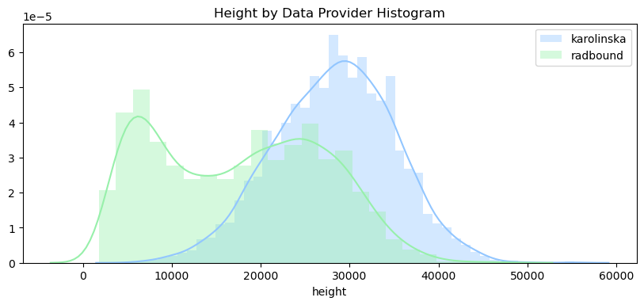

```python
plt.subplots(figsize=(10,4), dpi=100)
sns.distplot( res_df.loc[res_df.data_provider=='karolinska', "height"] ,label="karolinska")
sns.distplot( res_df.loc[res_df.data_provider=='radboud', "height"] , label="radbound")

plt.title('Height by Data Provider Histogram')
plt.legend();
```

```python
res_df.groupby(['data_provider']).agg(['mean', 'std'])
```

| data_provider | width mean | width std | height mean | height std |
| --- | --- | --- | --- | --- |
| karolinska | 25528.524377 | 7062.507970 | 28225.09824 | 6753.511221 |
| radboud | 11876.762791 | 7668.596324 | 17573.15969 | 9488.856674 |

- Overall, **Karolinksa** has higher resolution images, both width and height
- Same insights for lower level resolutions of the images
- For backup plan, if only stick to one provider, Karolinksa has higher resolution but less granular masks

# Suspicious Images

## Images with No Masks

```python
# get list of all images and masks
img_images = [img.split('/')[-1].split('.')[0] for img in images_list]
mask_images = [mask.split('/')[-1].split('_')[0] for mask in masks_list]

img_set = set(img_images)
mask_set = set(mask_images)
```

```python
# images with no masks
img_no_masks = list(img_set.difference(mask_set))
```

```python
print(f"there are {len(img_no_masks)} images with no masks")
```

```
there are 100 images with no masks
```

## Mislabelled Images

- Mislabel between the Gleason and ISUP Scores

```python
label_df.groupby(['isup_grade', 'gleason_score']).size()
```

```
isup_grade  gleason_score
0           0+0              1925
            negative          967
1           3+3              2666
2           3+4              1342
            4+3                 1
3           4+3              1242
4           3+5                80
            4+4              1126
            5+3                43
5           4+5               849
            5+4               248
            5+5               127
dtype: int64
```

```python
label_df[(label_df['isup_grade'] == 2) & (label_df['gleason_score'] == '4+3')]
```

| image_id | data_provider | isup_grade | gleason_score |
| --- | --- | --- | --- |
| b0a92a74cb53899311acc30b7405e101 | karolinska | 2 | 4+3 |

## Masks with Background Only

- Not useful to have a mask with background only

```python
# initialize mask labels
res_df[0] = 0
res_df[1] = 0
res_df[2] = 0
res_df[3] = 0
res_df[4] = 0
res_df[5] = 0
```

```python
def get_mask_labels_count(row):
    biopsy = skimage.io.MultiImage(mask_dir + '/' + row['image'] + '_mask.tiff')
    temp = biopsy[-1][:, :, 0]
    # value counts of the mask labels
    mask_label_counts = pd.Series(temp.reshape(-1)).value_counts()
    row.update(mask_label_counts)

    return row
```

```python
res_df_mask_only = res_df[res_df['image'].isin(mask_images)]

res_df_mask_only = res_df_mask_only.apply(lambda row: get_mask_labels_count(row), axis=1)

res_df_mask_only = res_df_mask_only.rename(columns={'image':'image_id'}).set_index('image_id')

res_merge  = label_df.merge(res_df_mask_only.drop(['data_provider'], axis=1), left_index=True, right_index=True)
```

```python
# condition for all background only
bg_only = (res_merge[1] == 0.0) & (res_merge[2] == 0.0) & (res_merge[3] == 0.0) & (res_merge[4] == 0.0) & (res_merge[5] == 0.0)
res_merge[bg_only]
```

| image_id | data_provider | isup_grade | gleason_score | width | height | 0 | 1 | 2 | 3 | 4 | 5 |
| --- | --- | --- | --- | --- | --- | --- | --- | --- | --- | --- | --- |
| 3790f55cad63053e956fb73027179707 | karolinska | 0 | 0+0 | 25600 | 31744 | 3174400.0 | 0.0 | 0.0 | 0.0 | 0.0 | 0.0 |
| 4a2ca53f240932e46eaf8959cb3f490a | karolinska | 1 | 3+3 | 29696 | 30208 | 3504128.0 | 0.0 | 0.0 | 0.0 | 0.0 | 0.0 |
| aaa5732cd49bffddf0d2b7d36fbb0a83 | karolinska | 1 | 3+3 | 28672 | 28160 | 3153920.0 | 0.0 | 0.0 | 0.0 | 0.0 | 0.0 |
| e4215cfc8c41ec04a55431cc413688a9 | karolinska | 2 | 3+4 | 28672 | 19968 | 2236416.0 | 0.0 | 0.0 | 0.0 | 0.0 | 0.0 |

- There are 4 images with background only and these are not helpful in identifying prostate cancer.
- Could me a mistake
- Example below, supposedly `isup_grade=2` but then no other mask label except background

```
Image name: e4215cfc8c41ec04a55431cc413688a9
ISUP Grade: 2
Data Provider: karolinska
Original Resolution of Image: (1792, 1248)
Original resolution of Mask: (1792, 1248)
```

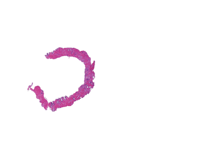

```python
preview_img_mask((400, 600), 'e4215cfc8c41ec04a55431cc413688a9')
```

[output not shown]

```python
res_merge = res_merge[~bg_only]
```

## `isup_grade > 0` but No Cancerous Labelled

- same cases for `data_provider=radboud`

```python
isup_no_cancer = (res_merge['isup_grade'] > 0) & (res_merge['data_provider'] == 'radboud') & (res_merge[3] == 0.0) & (res_merge[4] == 0.0)  & (res_merge[5] == 0.0)
```

```python
isup_no_cancer[isup_no_cancer==True]
```

```
image_id
004dd32d9cd167d9cc31c13b704498af    True
00d8a8c04886379e266406fdeff81c45    True
014006841b9807edc0ff277c4ab29b91    True
01dfcde514052a6dc35ea4407f41d6e1    True
053a397c936bffc98e62367a81d6c905    True
                                    ...
eec44ee55b0dfc4a00a728d459a6c5bb    True
ef65ea2c6fcec3156ffb0034135f8d55    True
f1a7f32a0a9ed7c50796a10e150df72b    True
fe79209ab178c89a9be62bc05b63f083    True
ffc70bf605de30aaa936533397a29d9c    True
Length: 85, dtype: bool
```

```
Image name: 004dd32d9cd167d9cc31c13b704498af
ISUP Grade: 1
Data Provider: radboud
Original Resolution of Image: (512, 1408)
Original resolution of Mask: (512, 1408)
```

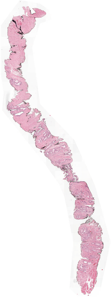

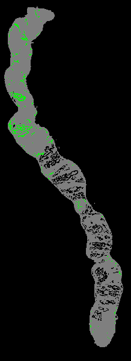

```python
preview_img_mask((400, 600), '004dd32d9cd167d9cc31c13b704498af')
```

```python
res_merge = res_merge[~isup_no_cancer]
```

# Conclusion of EDA & Labelled Data Cleansing

## EDA

- karolinksa and radboud has almost equal contribution to images
- overall `isup_grade` from 2-5 are evenly distributed
- Radboud has more even distributed `isup_grade`
- radbound has more granular mask labels
- karolinksa has higher resolution images overall

## Data Cleansing

The following was removed was list of images to be considered:

```python
label_df.shape
```

```
(10616, 3)
```

```python
res_merge.shape
```

```
(10427, 11)
```

```python
# download images
res_merge.to_csv('final_images.csv', index=True)
```